blog

# Analyzing my spotify listening history

Soul searching through my music choices.

Jul 30, 2020 • Bauke Brenninkmeijer • 156 min read

Analysis Music

- Yearly behaviour
- Daily behaviour

I like to have everything in my life tracked in some way. Preferably, knowingly (Looking at you, Facebook), cause it allows you to analyze it and find interesting things (Might be related with becoming a data scientist)! I've always been a fan of the features provided by [Last.fm](https://www.last.fm) to track you listening behaviour across apps and platforms. It allows you to see stuff like your favorite artists per month, or your afinity with certain genres over time like in the image below.

[figure not shown]

*Buuuuuut*, like Last.fm, most of these analyses are paid completely or partly. In the case of Last.fm, you get this plot for free but anything more will cost you some paper. I'm kinda cheap, so let's see if we can do it ourselves!

I wanted to have my listening history, and currently there is an [API call](https://developer.spotify.com/documentation/web-api/reference/player/get-recently-played/) that provides that functionality. However, I wanted to do this at the start of 2019 (Yeah, I didn't get around to doing this until now 😅) and this wansn't available back then, or at least I couldn't find it. Spotify, like many other companies, has an option to download your personal information. Unfortunately, this data only contained data for three months (they upped it to a year now, which is great!).

But, given this limitation, **the only way I could think of to get this was to ask Spotify for my personal data**. Under the GDPR, they are required to provide this information, so I thought this had a good shot. Well, after e-mailing back and forth a whole bunch of times, eventually I got in touch with the Data Privacy Office and they provided me with my complete listening history!

So that's the data that we'll be working with. Like I said, I requested the data in early 2019, so my history goes from my beginning of Spotify (ca. 2013) untill then. So lets see what we're dealing with.

I received one main file from spotify called `EndSong.json` which had json items as follows. In total, I got 39,229 songs played, which is quite a lot and definitely enough to do some interesting things with!

```
{
    "ts":"2013-10-09 20:03:57 UTC",
    "username":"xxxxxxxxxx",
    "platform":"xxxxxxx",
    "ms_played":"5969",
    "conn_country":"NL",
    "ip_addr_decrypted":"xx.xx.xx.xx",
    "user_agent_decrypted": "xxxxxxxxxxx",
    "master_metadata_track_name":"You Make Me",
    "master_metadata_album_artist_name":"Avicii",
    "master_metadata_album_album_name":"You Make Me",
    "reason_start":"click-row",
    "reason_end":"click-row",
    "shuffle":false,
    "skipped":false,
    "offline":false,
    "offline_timestamp":"0",
    "incognito_mode":false,
    "metro_code":"0",
    "longitude":0,
    "latitude":0
}
```

For our analysis, we're gonna use the ol' trusty [Pandas](https://pandas.pydata.org/). The data is in the json-lines format, so we use the python [json-lines](https://pypi.org/project/json-lines/) package to read our data. We'll also drop some useless columns and convert the timestamp column to a python datetime object. Furthermore, we use the UTF-8 encoding while reading our data, to support tokens that would otherwise be malformed like the ë character. Lastly, we also create separate columns for many of our time attributes like year, month and day, since this makes it easy for filtering during plotting.

**Tip:** The json-lines format puts a json object on each separate line, and allows for very dense information packaging in json files. Before I knew this, I was reading the data as a string, converting true->True and false->False, to match python syntax and then using the ast package to interpret the string as a python object. That also worked ok, but this is much better. 😊

```python
lines = []
for i in json_lines.reader(open('data/EndSong.json', encoding='utf-8')):
    lines.append(i)
df = pd.DataFrame(lines)
```

```python
#collapse-hide
df = df.drop(['username', 'user_agent_decrypted', 'incognito_mode', 'platform', 'ip_addr_decrypted'], axis=1)
df.ts = pd.to_datetime(df.ts)
df['date'] = df.ts.dt.date
df['year'] = df.ts.dt.year
df['month'] = df.ts.dt.month
df['day'] = df.ts.dt.day
df['dow'] = df.ts.dt.dayofweek
df['hour'] = df.ts.dt.hour
df.head(4)
```

|  | ts | ms_played | conn_country | master_metadata_track_name | master_metadata_album_artist_name | master_metadata_album_album_name | reason_start | reason_end | shuffle | skipped | ... | city | region | episode_name | episode_show_name | date | year | month | day | dow | hour |
| --- | --- | --- | --- | --- | --- | --- | --- | --- | --- | --- | --- | --- | --- | --- | --- | --- | --- | --- | --- | --- | --- |
| 0 | 2013-10-09 20:24:30+00:00 | 15010 | NL | Wild for the Night (feat. Skrillex & Birdy Nam... | A$AP Rocky | LONG.LIVE.A$AP (Deluxe Version) | unknown | click-row | False | False | ... | NaN | NaN | NaN | NaN | 2013-10-09 | 2013 | 10 | 9 | 2 | 20 |
| 1 | 2013-10-09 20:19:20+00:00 | 68139 | NL | Buzzin' | OVERWERK | The Nthº | unknown | click-row | False | False | ... | NaN | NaN | NaN | NaN | 2013-10-09 | 2013 | 10 | 9 | 2 | 20 |
| 2 | 2013-10-09 20:21:54+00:00 | 23643 | NL | Blue | Gemini | Blue EP | unknown | click-row | False | False | ... | NaN | NaN | NaN | NaN | 2013-10-09 | 2013 | 10 | 9 | 2 | 20 |
| 3 | 2013-10-09 20:20:29+00:00 | 68063 | NL | Blue | Gemini | Blue EP | unknown | click-row | False | False | ... | NaN | NaN | NaN | NaN | 2013-10-09 | 2013 | 10 | 9 | 2 | 20 |

4 rows × 25 columns

## Yearly behaviour

One of the first things I'm curious to see is how my usage of spotify has changed over the years. For this, we can easily plot the number of songs player by year and by month.

**Note:** All my plots will be created using Altair. This is mainly because fastpages has the best support for this. But, I have taken this opportunity to become really familiar with the nooks and crannies of Altair. My previous go-tos are and likely still will be for most: matplotlib and seaborn.

We're using the LA Times vega lite theme. We can set altair to use this with the following line.

```python
alt.themes.enable('latimes')
```

```
ThemeRegistry.enable('latimes')
```

```python
#collapse-hide
t = (
    df.ts.dt  # Use the datetime attributes of the ts column
    .to_period('D')  # Convert the ts column to a 'date' period. So the timestamp is reduced to a date like '28-2-2020'.
    .value_counts()  # Counts the frequency of all days (i.e. count how many songs were played that day).
    .to_timestamp()  # The index is a RangeIndex after the `to_period`, so we convert it back to a datetime.
    .to_frame()      # Altair wants dataframes, so we convert it to a dataframe.
    .reset_index()   # Make the datetime index a separate column instead of the index.
    .rename(columns={'index': 'date', 'ts': 'listens'})  # Rename the columns to be descriptive
)

yearly = alt.Chart(t).mark_bar(size=30).encode(
    alt.X('year(date)', title='Year'),
    alt.Y('sum(listens)', title='Listens'),
    tooltip=['sum(listens)']
)

monthly = alt.Chart(t).mark_bar().encode(
    alt.X('yearmonth(date)', title='Month'),
    alt.Y('sum(listens)', title='Listens'),
    tooltip=['sum(listens)', 'yearmonth(date)'],
)

# Altair allows really easy formatting, having horizontal concatenation with the | operator
yearly | monthly
```

[interactive chart not shown]

In the plots above you see my total songs listened. It immediately becomes clear that I got my data in early 2019, given the drop in 2019 and lack of data in 2020. But what is interesting is the steady increasing line the previous years. It shows that I slowly started using spotify more and more. The start coincides with when I started paying for Spotify as well, which is not very surprising (Yay for no commercials 😃).

When looking at the number of songs per month, we can still see a decline in listening activity since the spike at October 2018. The peak that ranges from September 2018 to November 2018 can be explained by me starting a new internship where I was playing spotify while working the whole day. In October my total songs listened more than doubled compared to only two months earlier (1615 to 3273 songs played).

## Daily behaviour

Well, I'm already learning a lot about Altair, cause creating this plot in its current form easily took three hours. Altair does not like it when you aggregate a value in several places. *But* the result is also quite a nice visual. I plotted the daily distribution per hours per year. Now, the value is the sum of the whole year, so it's no wonder that the differences are really similar to what we say in the yearly distribution. More interesting would be the percentage per hour per year, which would tell me something about my listening behaviour throughout the years.

*The yearly visuals only show 2016 till 2019, because the others years don't have enough data.*

There are several noteworthy things:

1. **In 2016**, there was a big spike between 13:00 and 14:00. 2016 is split between my third and fourth year at university, of which in the fourth year I also was on the board of the [e-sports association](https://dorans.nl/). I just barely didn't have enough credits to get my bachelor's degree in my third year, so my fourth year was pretty empty. The combination likely contributed to many days where I had lunch and then closed myself of with music, to work on association matters.
2. **In 2016**, there is a big spike at 9:00. This makes sense, because that was always the time I was cycling to my university. Over the years, I started listening to podcasts more, which is why you can see the 9:00 value decline over 4 years.
3. **In 2018 and 2019**, my listening during evening hours decreased quite significantly. Earlier, I had a spike at 22:00 but this completely faded during the first month of 2019. What happened? Not sure, to be frank. It might be that I had more nights planned with friends?
4. **In 2017 and 2018**, I somehow play 4% of my music daily before 7:00. Now, this is essentially impossible since I almost never get up before 7. I'm not sure why this is shown to be the case.

```python
#collapse-hide
# Create sum per hour per year
selection_sum = df.groupby(['year', 'hour']).size().reset_index().rename(columns={0: 'count'})

# Create percentage per hour per year
selection_perc = selection_sum.copy()
yearly_counts = df.ts.dt.to_period('Y').value_counts()
for year in yearly_counts.index:
    selection_perc.loc[selection_perc.year == year.year, 'count'] = selection_perc.loc[selection_perc.year == year.year, 'count'] / yearly_counts[year.year]
selection_perc = selection_perc.round(2)

# Plot the total listens per hour
total = alt.Chart(selection_sum).mark_bar().encode(
    alt.X('hour:O', title='Hour'),
    alt.Y('sum(count):Q', title='Listens'),
).properties(title='Sum of listens per hour')


label = alt.selection_single(
    encodings=['x'], # limit selection to x-axis value
    on='mouseover',  # select on mouseover events
    nearest=True,    # select data point nearest the cursor
    empty='none'     # empty selection includes no data points
)

monthly = alt.Chart().mark_line().encode(
    alt.X('hour:O', title='Hour'),
    alt.Y('count:Q', title='Listens'),
    color='year:N',
).transform_filter(alt.FieldOneOfPredicate(field='year', oneOf=[2016, 2017, 2018, 2019]))

# Plot sum per hour per year
sum_per_hour_per_year = alt.layer(
    monthly.properties(
        title='Sum of listens per hour per year'
    ), # base line chart

#     add a rule mark to serve as a guide line
    alt.Chart().mark_rule(color='#aaa').encode(
#         alt.X('hour'),
        x='hour:O'
    ).transform_filter(label),

    # add circle marks for selected time points, hide unselected points
    monthly.mark_circle().encode(
        opacity=alt.condition(label, alt.value(1), alt.value(0))
    ).add_selection(label),

#     # add white stroked text to provide a legible background for labels
    monthly.mark_text(align='left', dx=5, dy=-5, stroke='white', strokeWidth=2).encode(
        text='sum(count):Q'
    ).transform_filter(label),

    # add text labels for stock prices
    monthly.mark_text(align='left', dx=5, dy=-5).encode(
        alt.Text('sum(count):Q'),
#         text='sum(listens):Q'
    ).transform_filter(label),

    data = selection_sum
).properties(
    width=400,
    height=300
)

# Plot percentage per hour per year
perc_per_hour_per_year = alt.layer(
    monthly.properties(
        title='Percentage of listens per hour per year'
    ),
    alt.Chart().mark_rule(color='#aaa').encode(
        x='hour:O'
    ).transform_filter(label),

    monthly.mark_circle().encode(
        opacity=alt.condition(label, alt.value(1), alt.value(0))
    ).add_selection(label),

    monthly.mark_text(align='left', dx=5, dy=-5, stroke='white', strokeWidth=2).encode(
        text='sum(count):Q'
    ).transform_filter(label),

    monthly.mark_text(align='left', dx=5, dy=-5).encode(
        alt.Text('sum(count):Q'),
    ).transform_filter(label),

    data = selection_perc
).properties(
    width=400,
    height=300
)

total | sum_per_hour_per_year | perc_per_hour_per_year
```

[interactive chart not shown]

```python
artist_ids = []
genres = []
for artist in tqdm_notebook(df.master_metadata_album_artist_name):
    try:
        response = spotify.search(artist, type='artist')
        artist_id = response.get('artists').get('items')[0].get('uri')
        artist_genres = response.get('artists').get('items')[0].get('genres')
    except Exception as e:
        print(e)
        print(response)
        artist_id = ''
        artist_genres = []
    genres.append(artist_genres)
    artist_ids.append(artist_id)
print(len(artist_ids), len(genres))
```

[output not shown]

[output cut: 640 more lines]

[output not shown]

```python
genres_df = pd.DataFrame(genres)
genres_df.to_csv('genres.csv', index=False)

artist_ids_df = pd.DataFrame(artist_ids)
artist_ids_df.to_csv('artist_ids.csv', index=False)
```

```python
genres_df = pd.read_csv('genres.csv')
artist_ids_df = pd.read_csv('artist_ids.csv')
```

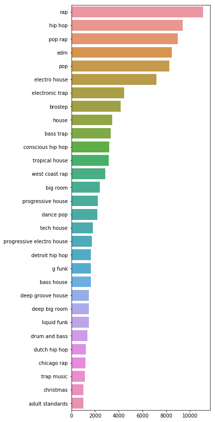

```python
top_genres = genres_df.apply(pd.Series.value_counts).apply(np.sum, axis=1).sort_values(ascending=False)[:30]
fig, ax = plt.subplots(figsize=(5, 15))
sns.barplot(ax=ax, y=top_genres.index, x=top_genres.values)
plt.show()
```

```python
track_ids = []
for track in tqdm_notebook(df.master_metadata_track_name):
    try:
        response = spotify.search(track.split(' ')[:2], type='track', limit=1)
        track_id = response.get('tracks').get('items')[0].get('uri')
#         artist_genres = response.get('artists').get('items')[0].get('genres')
    except Exception as e:
        print(e)
        print(track)
        track_id = ''
    track_ids.append(track_id)
print(len(track_ids))
```

[output not shown]

[output cut: 2143 more lines]

[output not shown]

```python
pd.Series(track_ids).to_csv('track_ids.csv', index=False)
```

```python
track_ids = pd.read_csv('track_ids.csv')
```

```python
len(track_ids)
```

```
39229
```

```python
spotify.audio_analysis(track_ids[0]).keys()
```

```
dict_keys(['meta', 'track', 'bars', 'beats', 'tatums', 'sections', 'segments'])
```

```python
spotify.audio_analysis(track_ids[0])
```

```python
spotify.audio_features([track_ids[0], track_ids[1]])
```

```
[{'danceability': 0.613,
  'energy': 0.681,
  'key': 8,
  'loudness': -3.089,
  'mode': 1,
  'speechiness': 0.0778,
  'acousticness': 0.0287,
  'instrumentalness': 0,
  'liveness': 0.126,
  'valence': 0.619,
  'tempo': 97.621,
  'type': 'audio_features',
  'id': '45XhKYRRkyeqoW3teSOkCM',
  'uri': 'spotify:track:45XhKYRRkyeqoW3teSOkCM',
  'track_href': 'https://api.spotify.com/v1/tracks/45XhKYRRkyeqoW3teSOkCM',
  'analysis_url': 'https://api.spotify.com/v1/audio-analysis/45XhKYRRkyeqoW3teSOkCM',
  'duration_ms': 204664,
  'time_signature': 4},
 {'danceability': 0.563,
  'energy': 0.463,
  'key': 9,
  'loudness': -9.249,
  'mode': 0,
  'speechiness': 0.4,
  'acousticness': 0.65,
  'instrumentalness': 4.87e-06,
  'liveness': 0.0967,
  'valence': 0.276,
  'tempo': 149.571,
  'type': 'audio_features',
  'id': '6WUgEQwCbnaPrLf9V5K4HG',
  'uri': 'spotify:track:6WUgEQwCbnaPrLf9V5K4HG',
  'track_href': 'https://api.spotify.com/v1/tracks/6WUgEQwCbnaPrLf9V5K4HG',
  'analysis_url': 'https://api.spotify.com/v1/audio-analysis/6WUgEQwCbnaPrLf9V5K4HG',
  'duration_ms': 183287,
  'time_signature': 4}]
```

```python
track_features = []
for track in tqdm_notebook(df.master_metadata_track_name):
    try:
        response = spotify.search(track.split(' ')[:2], type='track', limit=1)
        track_id = response.get('tracks').get('items')[0].get('uri')
#         artist_genres = response.get('artists').get('items')[0].get('genres')
    except Exception as e:
        print(e)
        print(track)
        track_id = ''
    track_features.append(track_id)
print(len(track_ids))
```

```python
track_features = []
import math
for i in tqdm_notebook(range(0, len(track_ids))):
    if track_ids[i] == '':
        track_features_temp = None
    if isinstance(track_ids[i], float):
        if math.isnan(track_ids[i]):
            print('isnan')
            track_features_temp = None
    else:
        try:
            track_features_temp = spotify.audio_features(track_ids[i])
        except Exception as e:
            print(e)
            print(track_ids[i])
    track_features += track_features_temp if track_features_temp else [None]
print(len(track_features))
```

[output not shown]

[output cut: 1284 more lines]

[output not shown]

```python
pd.Series(track_features).to_csv('track_features.csv', index=False)
```

```python
track_features = pd.Series.from_csv('track_features.csv')
```

```python
for x in tqdm(range(len(track_features))):
    filler = {'danceability': None,
  'energy': None,
  'key': None,
  'loudness': None,
  'mode': None,
  'speechiness': None,
  'acousticness': None,
  'instrumentalness': None,
  'liveness': None,
  'valence': None,
  'tempo': None,
  'type': None,
  'id': None,
  'uri': None,
  'track_href': None,
  'analysis_url': None,
  'duration_ms': None,
  'time_signature': None}
    if track_features[x] is None:
        track_features[x] = filler
    if isinstance(track_ids[i], float):
        if math.isnan(track_ids[i]):
            track_features[x] = filler
```

```python
track_features_df = pd.DataFrame(track_features)
```

```python
track_features_df.to_csv('track_features_df.csv')
```

```python
track_features_df = pd.read_csv('track_features_df.csv').drop('Unnamed: 0', axis=1)
```

```python
track_features_df.columns
```

```
Index(['acousticness', 'analysis_url', 'danceability', 'duration_ms', 'energy',
       'id', 'instrumentalness', 'key', 'liveness', 'loudness', 'mode',
       'speechiness', 'tempo', 'time_signature', 'track_href', 'type', 'uri',
       'valence'],
      dtype='object')
```

```python
track_features_df.describe()
```

|  | acousticness | danceability | duration_ms | energy | instrumentalness | key | liveness | loudness | mode | speechiness | tempo | time_signature | valence |
| --- | --- | --- | --- | --- | --- | --- | --- | --- | --- | --- | --- | --- | --- |
| count | 38131.000000 | 38131.000000 | 3.813100e+04 | 38131.000000 | 38131.000000 | 38131.000000 | 38131.000000 | 38131.000000 | 38131.000000 | 38131.000000 | 38131.000000 | 38131.000000 | 38131.000000 |
| mean | 0.229174 | 0.670798 | 2.153865e+05 | 0.614641 | 0.065760 | 4.709606 | 0.181568 | -7.256677 | 0.597362 | 0.126330 | 121.241460 | 3.927277 | 0.449313 |
| std | 0.267589 | 0.159116 | 6.585594e+04 | 0.194569 | 0.210722 | 3.524272 | 0.140825 | 3.866346 | 0.490436 | 0.119944 | 30.038514 | 0.387834 | 0.230882 |
| min | 0.000000 | 0.000000 | 3.105200e+04 | 0.000020 | 0.000000 | 0.000000 | 0.000000 | -54.376000 | 0.000000 | 0.000000 | 0.000000 | 0.000000 | 0.000000 |
| 25% | 0.027700 | 0.573000 | 1.794490e+05 | 0.498000 | 0.000000 | 1.000000 | 0.092600 | -8.364000 | 0.000000 | 0.044900 | 96.062000 | 4.000000 | 0.273000 |
| 50% | 0.107000 | 0.681000 | 2.060000e+05 | 0.620000 | 0.000001 | 5.000000 | 0.121000 | -6.495000 | 1.000000 | 0.070500 | 122.961000 | 4.000000 | 0.433000 |
| 75% | 0.356000 | 0.791000 | 2.398360e+05 | 0.745000 | 0.000355 | 8.000000 | 0.229000 | -5.107000 | 1.000000 | 0.176000 | 144.004000 | 4.000000 | 0.619000 |
| max | 0.996000 | 0.974000 | 3.391040e+06 | 1.000000 | 0.997000 | 11.000000 | 0.979000 | 0.428000 | 1.000000 | 0.954000 | 216.429000 | 5.000000 | 0.989000 |

```python
from pandas_summary import DataFrameSummary
DataFrameSummary(track_features_df).summary()
```

|  | acousticness | analysis_url | danceability | duration_ms | energy | id | instrumentalness | key | liveness | loudness | mode | speechiness | tempo | time_signature | track_href | type | uri | valence |
| --- | --- | --- | --- | --- | --- | --- | --- | --- | --- | --- | --- | --- | --- | --- | --- | --- | --- | --- |
| count | 38131 | NaN | 38131 | 38131 | 38131 | NaN | 38131 | 38131 | 38131 | 38131 | 38131 | 38131 | 38131 | 38131 | NaN | NaN | NaN | 38131 |
| mean | 0.229174 | NaN | 0.670798 | 215387 | 0.614641 | NaN | 0.0657602 | 4.70961 | 0.181568 | -7.25668 | 0.597362 | 0.12633 | 121.241 | 3.92728 | NaN | NaN | NaN | 0.449313 |
| std | 0.267589 | NaN | 0.159116 | 65855.9 | 0.194569 | NaN | 0.210722 | 3.52427 | 0.140825 | 3.86635 | 0.490436 | 0.119944 | 30.0385 | 0.387834 | NaN | NaN | NaN | 0.230882 |
| min | 0 | NaN | 0 | 31052 | 1.99e-05 | NaN | 0 | 0 | 0 | -54.376 | 0 | 0 | 0 | 0 | NaN | NaN | NaN | 0 |
| 25% | 0.0277 | NaN | 0.573 | 179449 | 0.498 | NaN | 0 | 1 | 0.0926 | -8.364 | 0 | 0.0449 | 96.062 | 4 | NaN | NaN | NaN | 0.273 |
| 50% | 0.107 | NaN | 0.681 | 206000 | 0.62 | NaN | 1.21e-06 | 5 | 0.121 | -6.495 | 1 | 0.0705 | 122.961 | 4 | NaN | NaN | NaN | 0.433 |
| 75% | 0.356 | NaN | 0.791 | 239836 | 0.745 | NaN | 0.000355 | 8 | 0.229 | -5.107 | 1 | 0.176 | 144.004 | 4 | NaN | NaN | NaN | 0.619 |
| max | 0.996 | NaN | 0.974 | 3.39104e+06 | 1 | NaN | 0.997 | 11 | 0.979 | 0.428 | 1 | 0.954 | 216.429 | 5 | NaN | NaN | NaN | 0.989 |
| counts | 38131 | 38131 | 38131 | 38131 | 38131 | 38131 | 38131 | 38131 | 38131 | 38131 | 38131 | 38131 | 38131 | 38131 | 38131 | 38131 | 38131 | 38131 |
| uniques | 1949 | 3873 | 767 | 3665 | 932 | 3873 | 1642 | 12 | 999 | 3257 | 2 | 1055 | 3561 | 5 | 3873 | 1 | 3873 | 1052 |
| missing | 1098 | 1098 | 1098 | 1098 | 1098 | 1098 | 1098 | 1098 | 1098 | 1098 | 1098 | 1098 | 1098 | 1098 | 1098 | 1098 | 1098 | 1098 |
| missing_perc | 2.80% | 2.80% | 2.80% | 2.80% | 2.80% | 2.80% | 2.80% | 2.80% | 2.80% | 2.80% | 2.80% | 2.80% | 2.80% | 2.80% | 2.80% | 2.80% | 2.80% | 2.80% |
| types | numeric | categorical | numeric | numeric | numeric | categorical | numeric | numeric | numeric | numeric | bool | numeric | numeric | numeric | categorical | constant | categorical | numeric |

```python
track_features_df.dropna(subset=['energy', 'danceability'])
```

[output not shown]

38131 rows × 18 columns

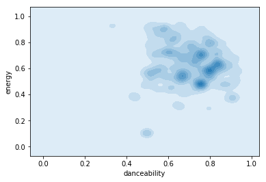

```python
sns.kdeplot(data=track_features_df.dropna().danceability, data2=track_features_df.dropna().energy, shade=True)
```

```python
plt.show()
```